# 05-viz

Professor Shannon Ellis

2023-10-17

# Effective Data Visualization

Slides modified from [datascienceinabox.org](https://datasciencebox.org/)

## Q&A

> Q: I just think it’s a bit fast and I would appreciate if you made sure to show like how to import and stuff rather then jumping to the final product  
> A: That’s really valuable feedback. I don’t think you’re alone. I’m going to work to better get everyone on the same page going forward.

Note: a handful of comments on needing more time on joins & pivots…which makes sense! They’re new :)

## Course Announcements

**Due Dates**:

- **Lab 03** due Friday (1/27; 11:59 PM)
- Lecture Participation survey “due” after class

**Course Announcements**:

- HW01 can be submitted by tonight for full credit (datahub issues)
- Lab02 Ans Posted
- HW02 Now Available
- My OH will now be at the tables along the back of this building

## Suggested Reading

- R4DS Chapter 28: [Graphics for Communication](https://r4ds.had.co.nz/graphics-for-communication.html)
- The Glamour of Graphics: [[video](https://www.rstudio.com/resources/rstudioconf-2020/the-glamour-of-graphics/)] [[slides](https://www.williamrchase.com/slides/assets/player/KeynoteDHTMLPlayer.html)] [[Prof’s slides inspired by Will’s talk](https://docs.google.com/presentation/d/1wT9M4J2O72s_pbcoqmaNLgBQJIUi2SzmvSmULmOWbSM/edit?usp=sharing)]

## Keep it simple

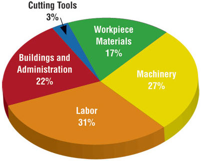

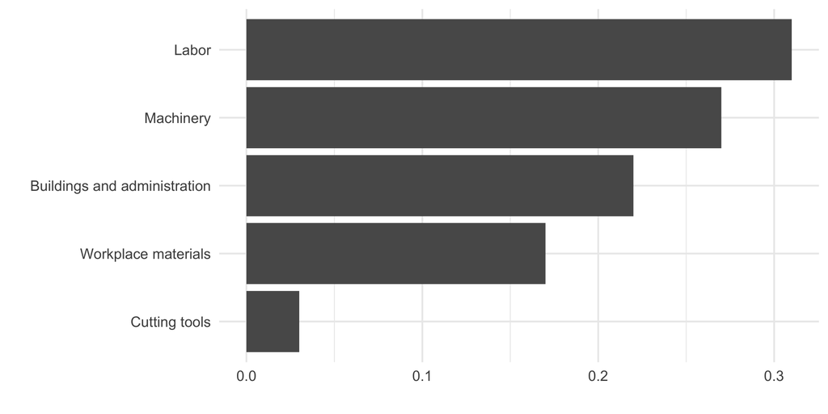

## Use color to draw attention

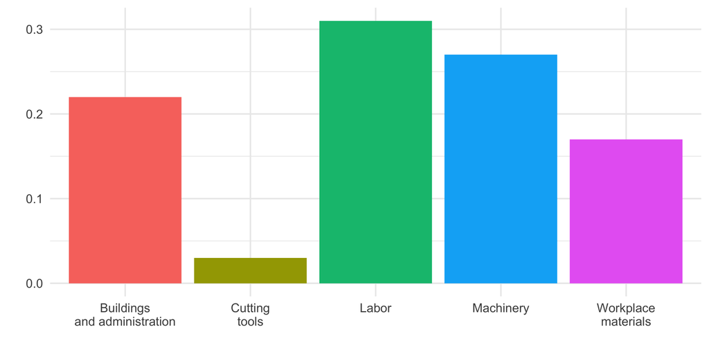

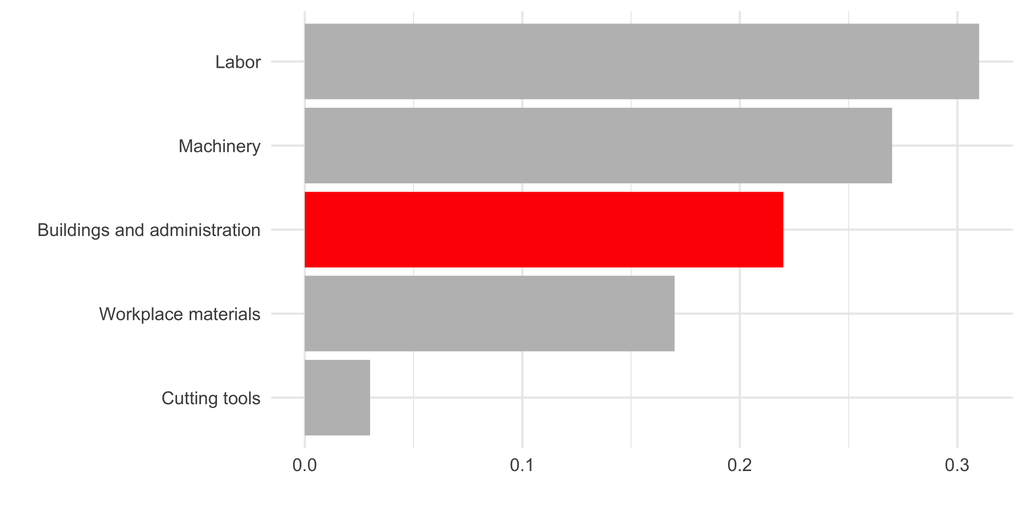

## Tell a story

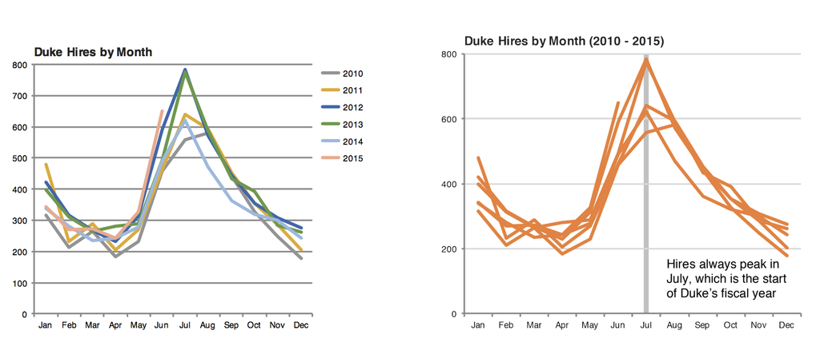

Credit: Angela Zoss and Eric Monson, Duke DVS

# Principles for effective visualizations

## Principles for effective visualizations

- Order matters
- Put long categories on the y-axis
- Keep scales consistent
- Select meaningful colors
- Use meaningful and nonredundant labels

## Data

In September 2019, YouGov survey asked 1,639 GB adults the following question:

> In hindsight, do you think Britain was right/wrong to vote to leave EU?
> - Right to leave
> - Wrong to leave
> - Don’t know

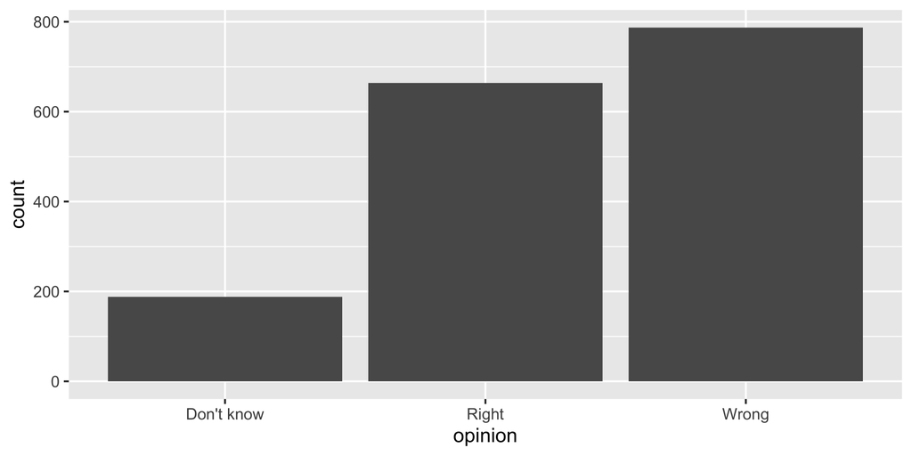

Source: [YouGov Survey Results](https://d25d2506sfb94s.cloudfront.net/cumulus_uploads/document/x0msmggx08/YouGov%20-%20Brexit%20and%202019%20election.pdf), retrieved Oct 7, 2019

## The Data: Code

```r
brexit <- tibble(
  opinion = c(
    rep("Right", 664), rep("Wrong", 787), rep("Don't know", 188)
  ),
  region = c(
    rep("london", 63), rep("rest_of_south", 241), rep("midlands_wales", 145), rep("north", 176), rep("scot", 39),
    rep("london", 110), rep("rest_of_south", 257), rep("midlands_wales", 152), rep("north", 176), rep("scot", 92),
    rep("london", 24), rep("rest_of_south", 49), rep("midlands_wales", 57), rep("north", 48), rep("scot", 10)
  )
)
```

## Order matters

**Alphabetical is rarely ideal**

- Plot
- Code

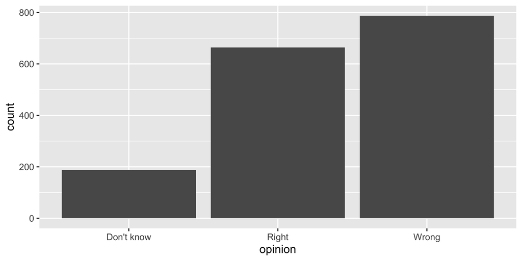

```r
ggplot(brexit, aes(x = opinion)) +
  geom_bar()
```

## Order by frequency

- Plot
- Code

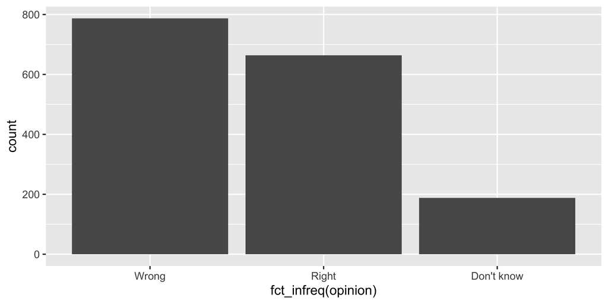

`fct_infreq`: Reorder factors’ levels by frequency

```r
ggplot(brexit, aes(x = fct_infreq(opinion))) +
  geom_bar()
```

## Clean up labels

- Plot
- Code

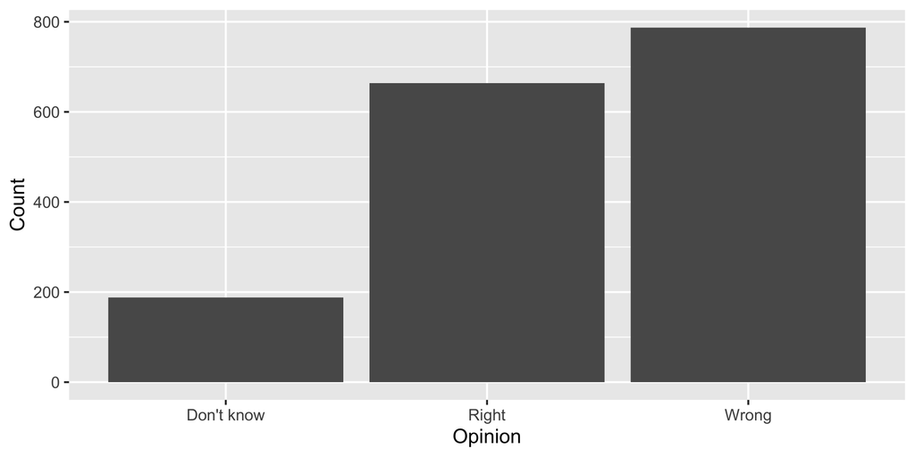

```r
ggplot(brexit, aes(x = opinion)) +
  geom_bar() +
  labs(
    x = "Opinion",
    y = "Count"
  )
```

## Avoiding Alphabetical Order

- Plot
- Code

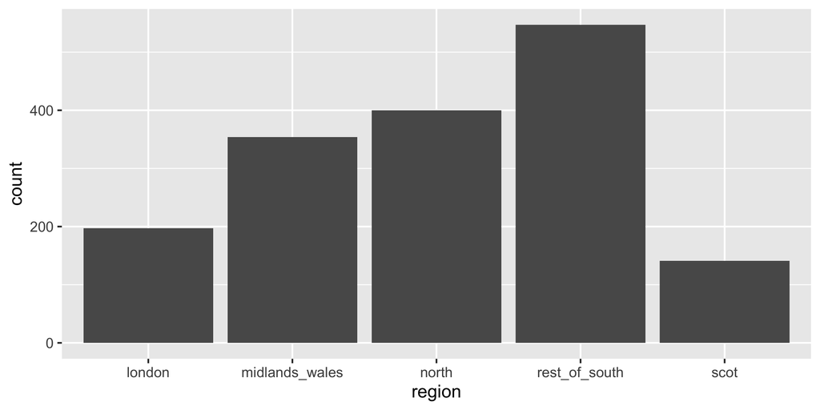

```r
ggplot(brexit, aes(x = region)) +
  geom_bar()
```

## Use inherent level order

- Relevel
- Plot

`fct_relevel`: Reorder factor levels using a custom order

```r
brexit <- brexit |>
  mutate(
    region = fct_relevel(
      region,
      "london", "rest_of_south", "midlands_wales", "north", "scot"
    )
  )
```

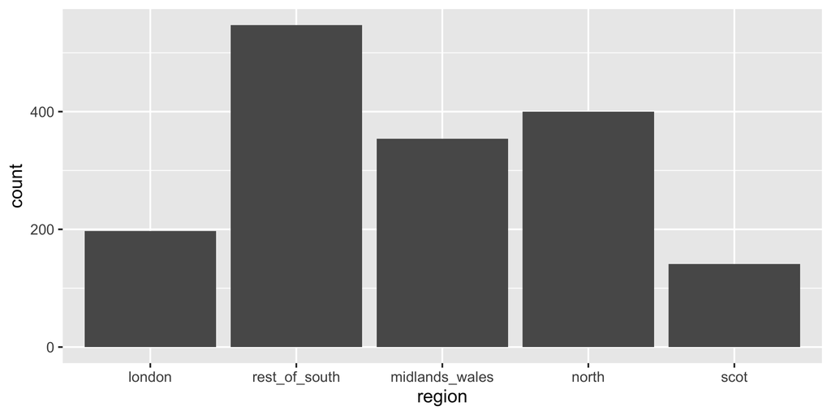

## Clean up labels

- Recode
- Plot

`fct_recode`: Change factor levels by hand

```r
brexit <- brexit |>
  mutate(
    region = fct_recode(
      region,
      London = "london",
      `Rest of South` = "rest_of_south",
      `Midlands / Wales` = "midlands_wales",
      North = "north",
      Scotland = "scot"
    )
  )
```

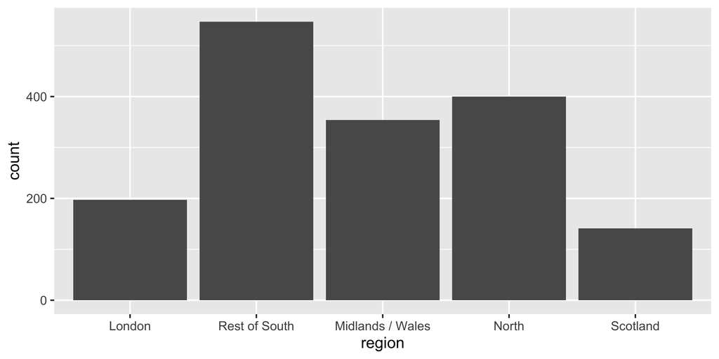

## Put long categories on the y-axis

**Long categories can be hard to read**

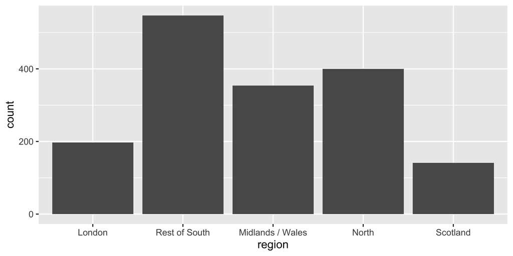

## Move them to the y-axis

- Plot
- Code

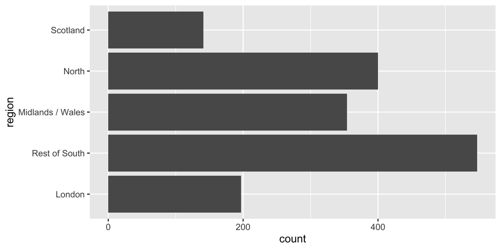

```r
ggplot(brexit, aes(y = region)) +
  geom_bar()
```

## And reverse the order of levels

- Plot
- Code

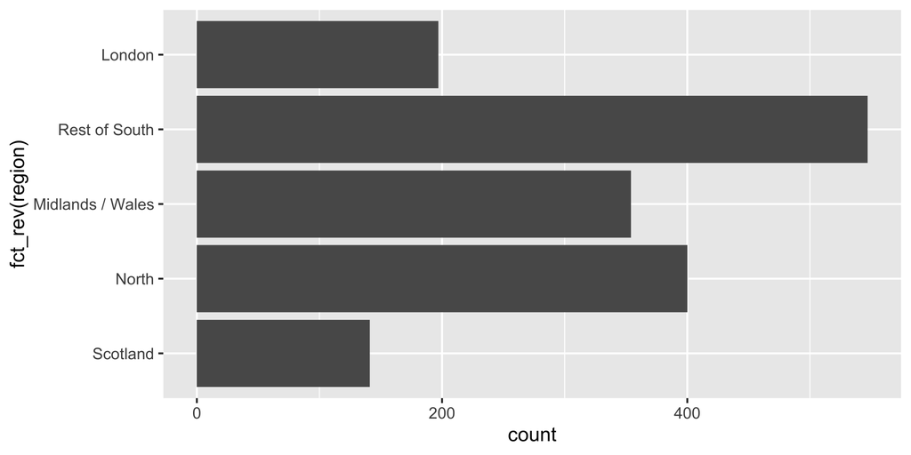

`fct_rev`: Reverse order of factor levels

```r
ggplot(brexit, aes(y = fct_rev(region))) +
  geom_bar()
```

## Clean up labels

- Plot
- Code

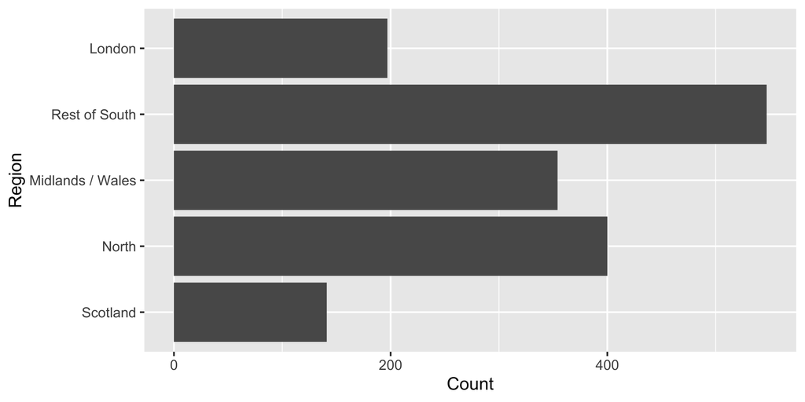

```r
ggplot(brexit, aes(y = fct_rev(region))) +
  geom_bar() +
  labs(
    x = "Count",
    y = "Region"
  )
```

# Pick a purpose

## Segmented bar plots can be hard to read

- Plot
- Code

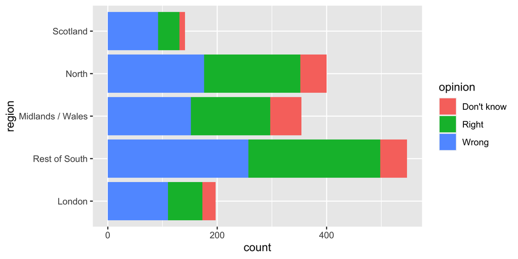

```r
ggplot(brexit, aes(y = region, fill = opinion)) +
  geom_bar()
```

## Use facets

- Plot
- Code

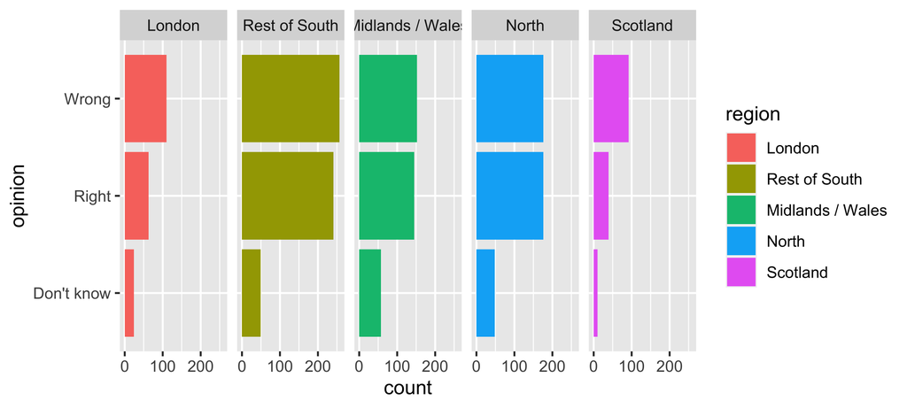

```r
ggplot(brexit, aes(y = opinion, fill = region)) +
  geom_bar() +
  facet_wrap(~region, nrow = 1)
```

## Avoid redundancy?

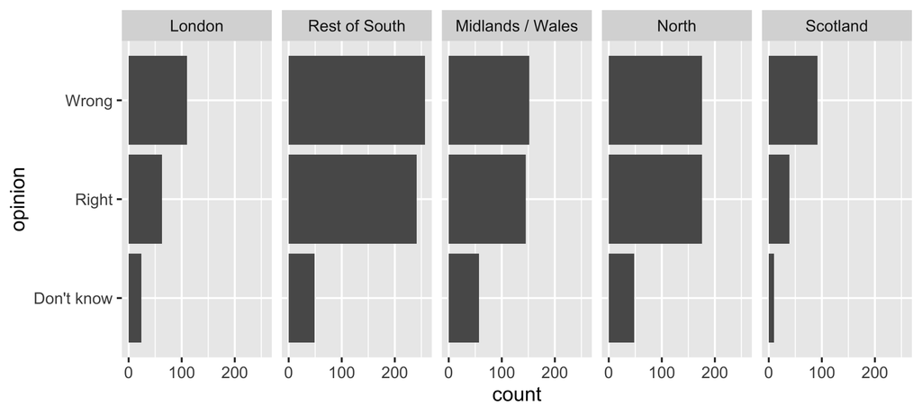

## Redundancy can help tell a story

- Plot
- Code

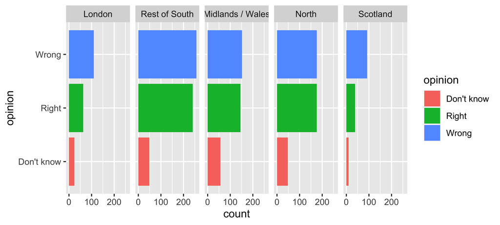

```r
ggplot(brexit, aes(y = opinion, fill = opinion)) +
  geom_bar() +
  facet_wrap(~region, nrow = 1)
```

## Be selective with redundancy

- Plot
- Code

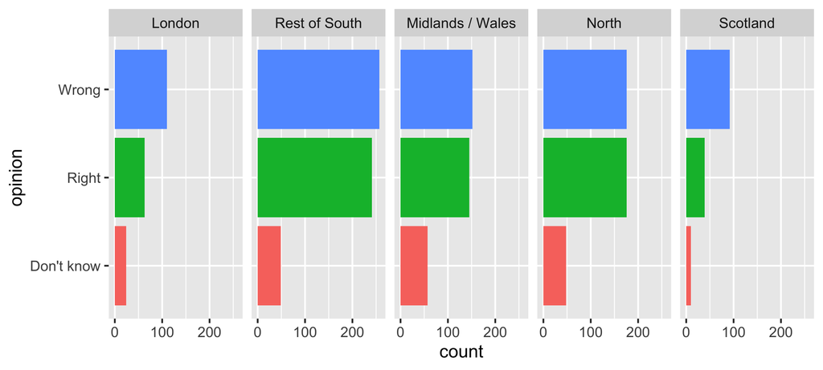

```r
ggplot(brexit, aes(y = opinion, fill = opinion)) +
  geom_bar() +
  facet_wrap(~region, nrow = 1) +
  guides(fill = "none")
```

## Use informative labels

- Plot
- Code

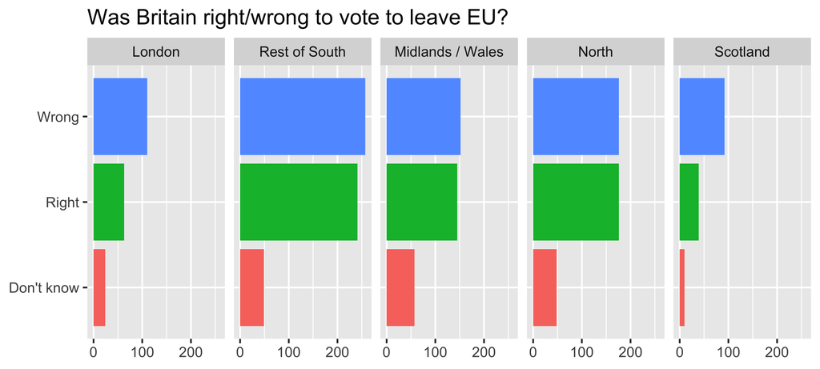

```r
ggplot(brexit, aes(y = opinion, fill = opinion)) +
  geom_bar() +
  facet_wrap(~region, nrow = 1) +
  guides(fill = "none") +
  labs(
    title = "Was Britain right/wrong to vote to leave EU?",
    x = NULL, y = NULL
  )
```

## A bit more info

- Plot
- Code

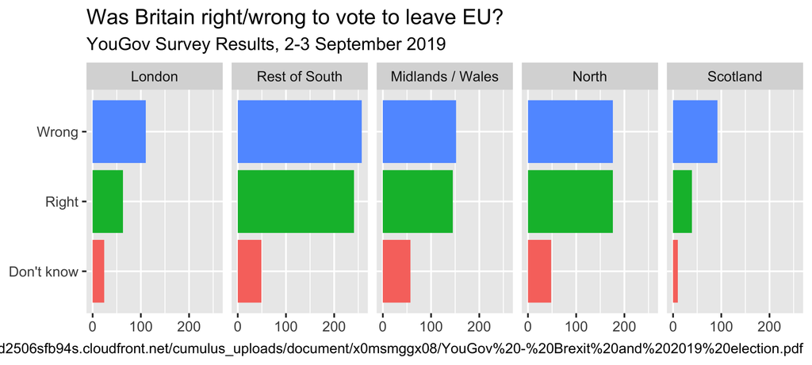

```r
ggplot(brexit, aes(y = opinion, fill = opinion)) +
  geom_bar() +
  facet_wrap(~region, nrow = 1) +
  guides(fill = "none") +
  labs(
    title = "Was Britain right/wrong to vote to leave EU?",
    subtitle = "YouGov Survey Results, 2-3 September 2019",
    caption = "Source: https://d25d2506sfb94s.cloudfront.net/cumulus_uploads/document/x0msmggx08/YouGov%20-%20Brexit%20and%202019%20election.pdf",
    x = NULL, y = NULL
  )
```

## Let’s do better

- Plot
- Code

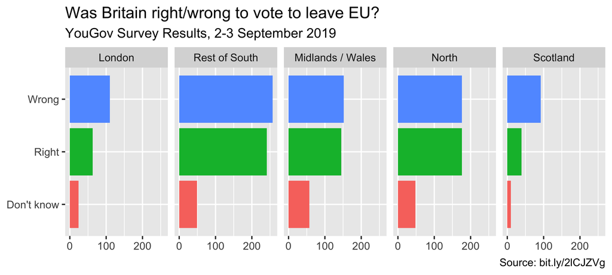

```r
ggplot(brexit, aes(y = opinion, fill = opinion)) +
  geom_bar() +
  facet_wrap(~region, nrow = 1) +
  guides(fill = "none") +
  labs(
    title = "Was Britain right/wrong to vote to leave EU?",
    subtitle = "YouGov Survey Results, 2-3 September 2019",
    caption = "Source: bit.ly/2lCJZVg",
    x = NULL, y = NULL
  )
```

## Fix up facet labels

- Plot
- Code

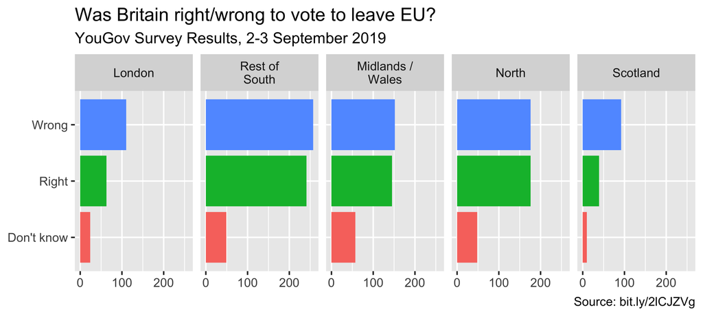

```r
ggplot(brexit, aes(y = opinion, fill = opinion)) +
  geom_bar() +
  facet_wrap(~region,
    nrow = 1,
    labeller = label_wrap_gen(width = 12)
  ) +
  guides(fill = "none") +
  labs(
    title = "Was Britain right/wrong to vote to leave EU?",
    subtitle = "YouGov Survey Results, 2-3 September 2019",
    caption = "Source: bit.ly/2lCJZVg",
    x = NULL, y = NULL
  )
```

# Select meaningful colors

## Rainbow colors not always best

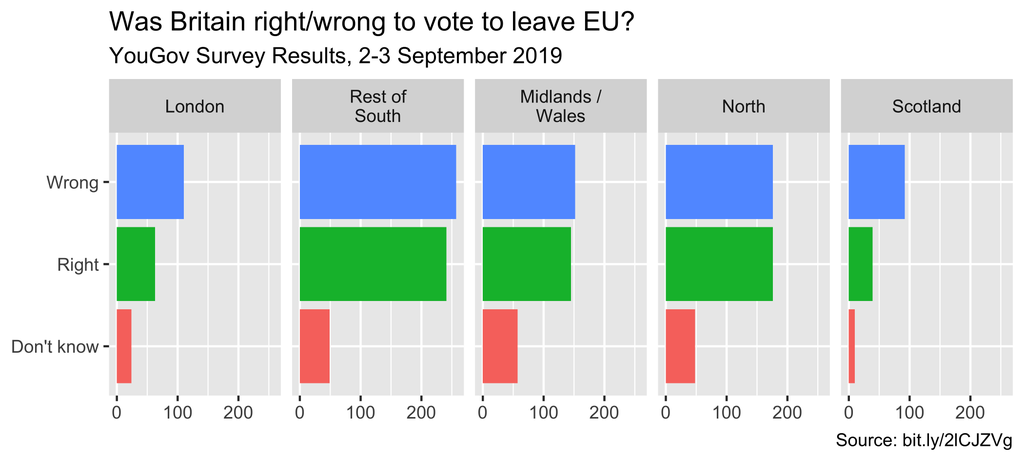

## Manually choose colors when needed

- Plot
- Code

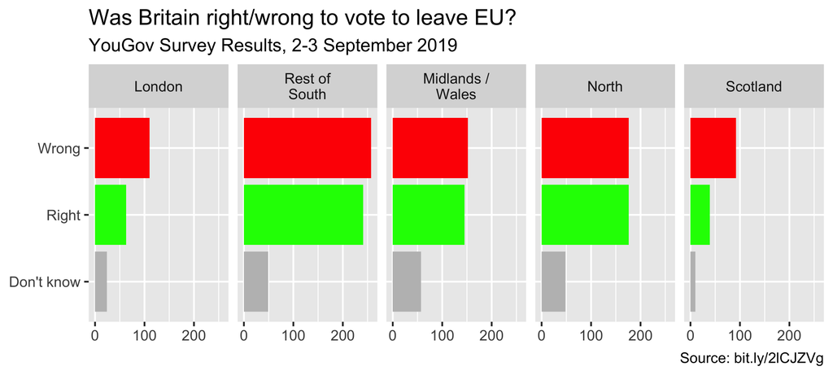

```r
ggplot(brexit, aes(y = opinion, fill = opinion)) +
  geom_bar() +
  facet_wrap(~region, nrow = 1, labeller = label_wrap_gen(width = 12)) +
  guides(fill = "none") +
  labs(title = "Was Britain right/wrong to vote to leave EU?",
       subtitle = "YouGov Survey Results, 2-3 September 2019",
       caption = "Source: bit.ly/2lCJZVg",
       x = NULL, y = NULL) +
  scale_fill_manual(values = c(
    "Wrong" = "red",
    "Right" = "green",
    "Don't know" = "gray"
  ))
```

## Choosing better colors

[colorbrewer2.org](https://colorbrewer2.org/)

[figure not shown]

## Use better colors

- Plot
- Code

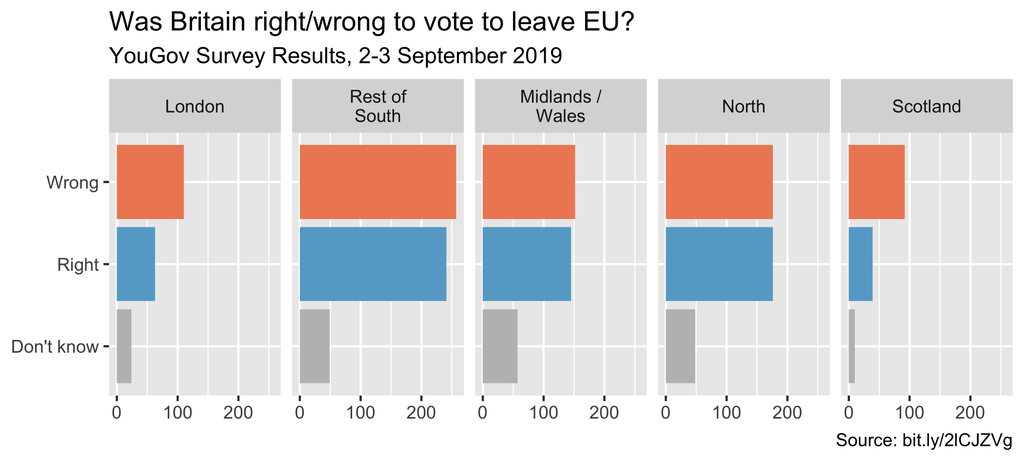

```r
ggplot(brexit, aes(y = opinion, fill = opinion)) +
  geom_bar() +
  facet_wrap(~region, nrow = 1, labeller = label_wrap_gen(width = 12)) +
  guides(fill = "none") +
  labs(title = "Was Britain right/wrong to vote to leave EU?",
       subtitle = "YouGov Survey Results, 2-3 September 2019",
       caption = "Source: bit.ly/2lCJZVg",
       x = NULL, y = NULL) +
  scale_fill_manual(values = c(
    "Wrong" = "#ef8a62",
    "Right" = "#67a9cf",
    "Don't know" = "gray"
  ))
```

## Select theme

- Plot
- Code

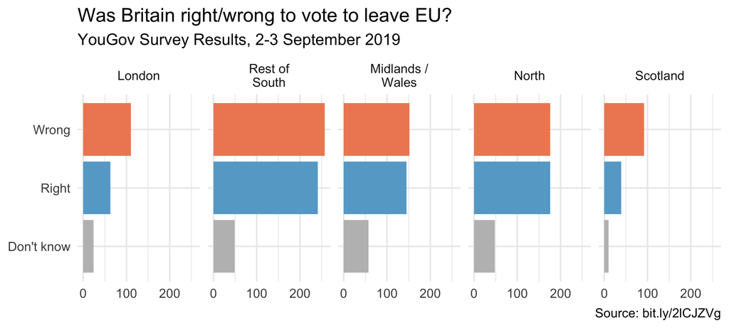

```r
ggplot(brexit, aes(y = opinion, fill = opinion)) +
  geom_bar() +
  facet_wrap(~region, nrow = 1, labeller = label_wrap_gen(width = 12)) +
  guides(fill = "none") +
  labs(title = "Was Britain right/wrong to vote to leave EU?",
       subtitle = "YouGov Survey Results, 2-3 September 2019",
       caption = "Source: bit.ly/2lCJZVg",
       x = NULL, y = NULL) +
  scale_fill_manual(values = c("Wrong" = "#ef8a62",
                               "Right" = "#67a9cf",
                               "Don't know" = "gray")) +
  theme_minimal()
```

`ggthemes` described [here](https://ggplot2.tidyverse.org/reference/ggtheme.html)

## Customize theme

- Plot
- Code

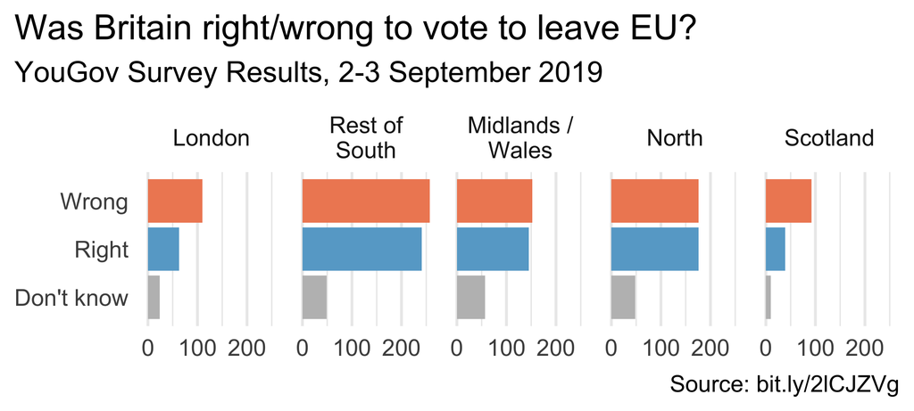

```r
ggplot(brexit, aes(y = opinion, fill = opinion)) +
  geom_bar() +
  facet_wrap(~region, nrow = 1, labeller = label_wrap_gen(width = 12)) +
  guides(fill = "none") +
  labs(title = "Was Britain right/wrong to vote to leave EU?",
       subtitle = "YouGov Survey Results, 2-3 September 2019",
       caption = "Source: bit.ly/2lCJZVg",
       x = NULL, y = NULL) +
  scale_fill_manual(values = c("Wrong" = "#ef8a62",
                               "Right" = "#67a9cf",
                               "Don't know" = "gray")) +
  theme_minimal(base_size = 16) +
  theme(plot.title.position = "plot",
        panel.grid.major.y = element_blank())
```

## Your Turn

- Read in the data ([Data slide](https://cogs137.github.io/website/content/lectures/05-viz-slides.html#/the-data-code))
- Think of at least three different ways to tell slightly different stories with these data
- Try to implement at least one of these ideas!

# Recap

- Can you determine what needs to be done to improve the effectiveness of your visualizations?
- Can you execute said improvements using `ggplot2`?
- Can you tell a story with data?

https://cogs137.github.io/website/